# Applied Statistic Assignment

Saioa Galvin

Contents

# 1 The Dramatic US Presidential Election 2000 (20 Marks)

To examine if voting for the Reform party was irregular in Palm Beach, Florida in 2000, I have examined a dataset of vote counts for the Reform party across the 67 counties in Florida over 1996 and 2000.

## 1.1 EDA

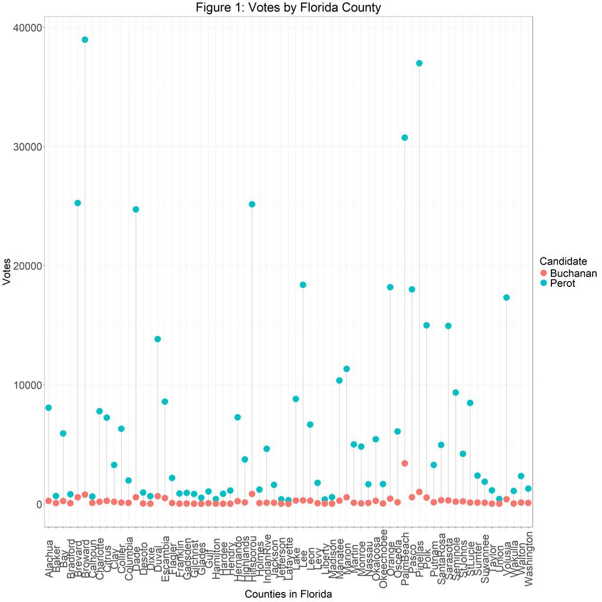

```r
# load data
elections <- read.table("BushGore.dat", header = TRUE)

# long format for plotting
elections_long <- pivot_longer(elections,
                        cols = c(Perot, Buchanan),
                        names_to = "Candidate",
                        values_to = "Votes")

# plotting votes by county
ggplot(elections_long, aes(x = County, y = Votes, group = County)) +
  geom_line(color = "gray70") +
  geom_point(aes(color = Candidate), size = 7) +
  theme(axis.text.x = element_text(angle = 90, vjust = 0.5)) +
  labs(title = "Figure 1: Votes by Florida County",
       x = "Counties in Florida",
       y = "Votes")
```

## 1.2 Creating a Model

To evaluate whether there was a significant difference in voting habits in Palm Beach County, Florida between 1996 and 2000, we can construct a model to compare voting habits across counties.

The full model is

$$m_{full} : \text{Buchanan}_i = \beta_0 +
\beta_1\text{Perot}_i + \epsilon_i, \\
\epsilon_i \sim N(0, \sigma^2) \text{ for } i = 1, \dots,
67,$$

where $\text{Buchanan}_i$ is the vote count for county $i$ in 2000, $\beta_0$ is the intercept, $\beta_1$ is the coefficient for vote count $\text{Perot}_i$ in county $i$ in 1996. We assume residual error $\epsilon_i$ is independently normally distributed, with constant variance $\sigma^2$.

To evaluate this model, we can run the following code in R.

```r
# fitting the full linear model
full_model <- lm(formula = Buchanan ~ Perot, data = elections)

# summary statistics
summary(full_model)
```

```
##
## Call:
## lm(formula = Buchanan ~ Perot, data = elections)
##
## Residuals:
##     Min      1Q  Median      3Q     Max
## -604.44  -66.82    2.53   33.45 2307.47
##
## Coefficients:
##              Estimate Std. Error t value Pr(>|t|)
## (Intercept)  1.081433  49.899462   0.022    0.983
## Perot        0.035735   0.004352   8.211 1.23e-11 ***
## ---
## Signif. codes:  0 '***' 0.001 '**' 0.01 '*' 0.05 '.' 0.1 ' ' 1
##
## Residual standard error: 317.3 on 65 degrees of freedom
## Multiple R-squared:  0.5091, Adjusted R-squared:  0.5016
## F-statistic: 67.41 on 1 and 65 DF,  p-value: 1.234e-11
```

As expected, from the summary of $m_{full}$ we see that the $p$-value for $\beta_1$ is very significant, indicating that the two years of voting habits across Florida are highly correlated. We can look at behaviour on a county-level in Figure 2.

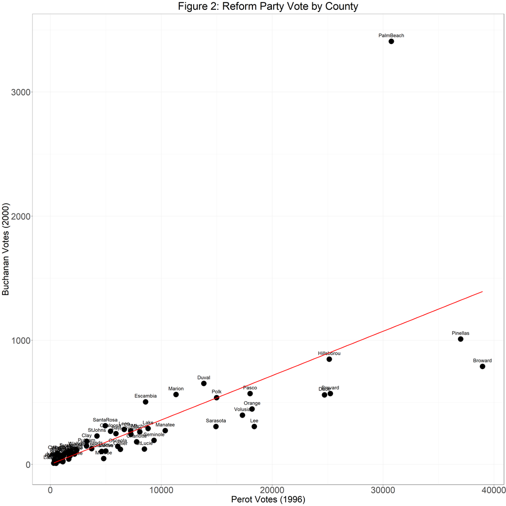

```r
# plotting model on data
ggplot(elections, aes(x = Perot, y = Buchanan, label = County)) +
  geom_point(size = 7) +
  geom_text(nudge_y = 50, size = 5) +
  geom_smooth(method = "lm", se = FALSE, color = "red") +
  labs(
    title = "Figure 2: Reform Party Vote by County",
    x = "Perot Votes (1996)",
    y = "Buchanan Votes (2000)"
  )
```

By plotting the regression line in Figure 2, we see that most points are fitted by $m_{full}$, apart from a few outliers. We see that the most significant outlier is Palm Beach.

Additionally, we can model the residuals to check assumptions and outliers.

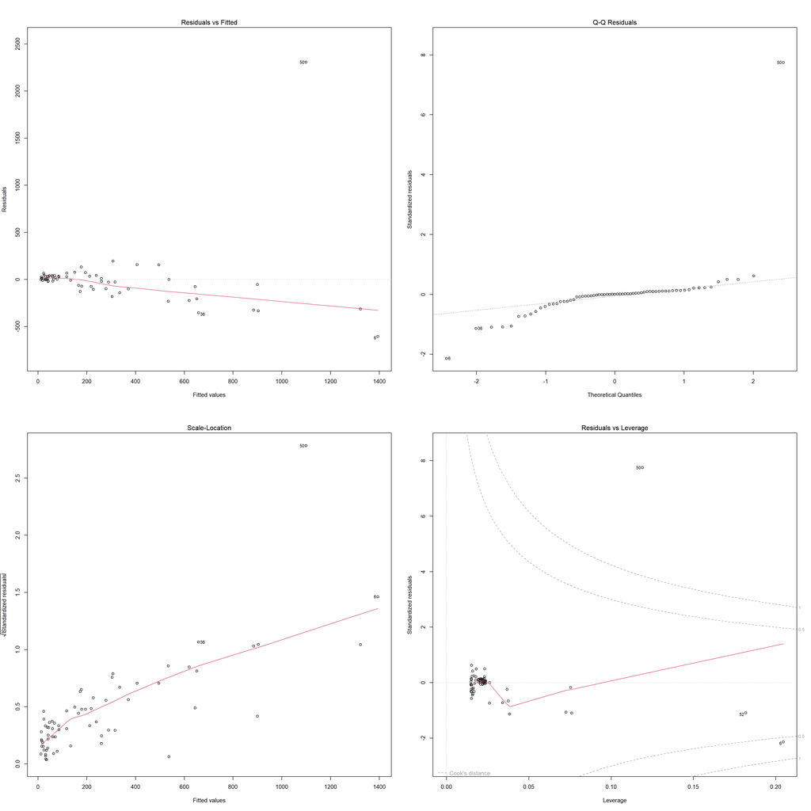

```r
# plotting residuals
par(mfrow = c(2,2))
plot(full_model)
```

This indicates that can compare our full model to a reduced model without Palm Beach,

$$m_{reduced} : \text{Buchanan}_i =
\beta_0 + \beta_1\text{Perot}_i + \epsilon_i, \\
\epsilon_i \sim N(0, \sigma^2) \text{ for } i = 1, \dots,
66,$$

where we have assumed that Palm Beach corresponds to $i = 67$ in $m_{full}$.

This will show the significance of changes in Palm Beach voting habits between 1996 and 2000, and give an indication of whether they were irregular in 2000.

```r
# fitting reduced model
reduced_elections <- elections[elections$County != "PalmBeach", ]
reduced_model <- lm(formula = Buchanan ~ Perot, data = reduced_elections)

# summary statistics
summary(reduced_model)
```

```
##
## Call:
## lm(formula = Buchanan ~ Perot, data = reduced_elections)
##
## Residuals:
##     Min      1Q  Median      3Q     Max
## -197.38  -45.49  -18.64   22.84  272.08
##
## Coefficients:
##              Estimate Std. Error t value Pr(>|t|)
## (Intercept) 45.689948  13.981299   3.268  0.00174 **
## Perot        0.024143   0.001281  18.847  < 2e-16 ***
## ---
## Signif. codes:  0 '***' 0.001 '**' 0.01 '*' 0.05 '.' 0.1 ' ' 1
##
## Residual standard error: 88.31 on 64 degrees of freedom
## Multiple R-squared:  0.8473, Adjusted R-squared:  0.8449
## F-statistic: 355.2 on 1 and 64 DF,  p-value: < 2.2e-16
```

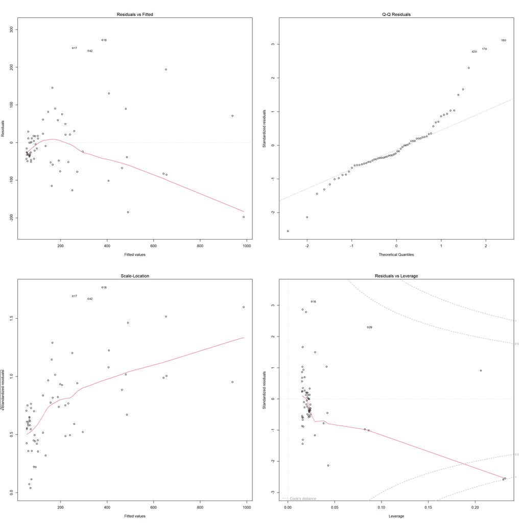

```r
# reduced model residuals
par(mfrow = c(2,2))
plot(reduced_model)
```

## 1.3 Evaluating Our Models

From the summary of $m_{reduced}$ we can evaluate model statistics to compare performance. Figure 3 shows this in table form.

```r
# creating a comparison table of summary statistics
summary_table <- data.frame(
  Statistic = c(
    "$R^2$",
    "Adjusted $R^2$",
    "$\\hat{\\beta}_0$",
    "95\\% CI for $\\hat{\\beta}_0$",
    "$\\hat{\\beta}_1$",
    "95\\% CI for $\\hat{\\beta}_1$"
  ),

  Full = c(
    round(summary(full_model)$r.squared, 4),
    round(summary(full_model)$adj.r.squared, 4),
    round(summary(full_model)$coef[1,1], 4),
    paste0("(", round(confint(full_model)[1,1],4), ", ", round(confint(full_model)[1,2],4), ")"),
    round(summary(full_model)$coef[2,1], 4),
    paste0("(", round(confint(full_model)[2,1],4), ", ", round(confint(full_model)[2,2],4), ")")
  ),

  Reduced = c(
    round(summary(reduced_model)$r.squared, 4),
    round(summary(reduced_model)$adj.r.squared, 4),
    round(summary(reduced_model)$coef[1,1], 4),
    paste0("(", round(confint(reduced_model)[1,1],4), ", ", round(confint(reduced_model)[1,2],4), ")"),
    round(summary(reduced_model)$coef[2,1], 4),
    paste0("(", round(confint(reduced_model)[2,1],4), ", ", round(confint(reduced_model)[2,2],4), ")")
  )
)

colnames(summary_table) <- c("Statistic", "$m_{full}$", "$m_{reduced}$")

kable(
  summary_table,
  caption = "Figure 3: Summary Table Comparing Full and Reduced Models",
  align = c("l", "c", "c"),
  format = "markdown",
  escape = FALSE
)
```

Figure 3: Summary Table Comparing Full and Reduced Models

| Statistic | $m_{full}$ | $m_{reduced}$ |
| --- | --- | --- |
| $R^2$ | 0.5091 | 0.8473 |
| Adjusted $R^2$ | 0.5016 | 0.8449 |
| $\hat{\beta}_0$ | 1.0814 | 45.6899 |
| 95% CI for $\hat{\beta}_0$ | (-98.5747, 100.7375) | (17.7591, 73.6208) |
| $\hat{\beta}_1$ | 0.0357 | 0.0241 |
| 95% CI for $\hat{\beta}_1$ | (0.027, 0.0444) | (0.0216, 0.0267) |

From this table we can deduce that $m_{reduced}$ has a much higher $R^2$ and Adjusted $R^2$.

Here,

$$R^2 = 1 - \frac{RSS}{TSS} = 1 -
\frac{\sum_{i=1}^n (\text{Buchanan}_i -
\widehat{\text{Buchanan}}_i)^2}{\sum_{i=1}^n (\text{Buchanan}_i -
\overline{\text{Buchanan}}_i)^2}$$

and

$$\text{Adjusted } R^2 = 1 - (1 -
R^2)\frac{n - 1}{n - p - 1},$$

where $n$ is the total number of observations in the model and $p$ is the total number of parameters.

The $R^2$ and Adjusted $R^2$ represent the goodness-of-fit of our models, so they can tell us how well votes for Perot in 1996 can predict votes for Buchanan in 2000 across the counties in Florida. Adjusted $R^2$ penalises unnecessary variables. As the Adjusted $R^2$ is much higher for $m_{reduced}$, we can see that votes in Palm Beach reduced the quality of our predictions. This supports the hypothesis that irregular voting was observed in Palm Beach.

The intercept estimate $\hat{\beta}_0$ represents an estimate of votes for Buchanan if votes for Perot were zero. Therefore it is more important to look at the slope estimate $\hat{\beta}_1$ in our analysis, as this represents the expected change in Buchanan votes given a 1-vote increase in Perot votes. We can see that the relationship between Buchanan votes and Perot votes changes between $m_{full}$ and $m_{reduced}$ as $\hat{\beta}_1$ decreases.

The 95% confidence intervals for our coefficient estimates can be written as

$$\hat{\beta}_k \pm t_{n - p, 0.975}
\times SE(\hat{\beta}_k) \text{ for } k = 0,1$$

where $t_{n - p, 0.975}$ is the $t$ statistic for our 95% CI with $n$ total number of observations and $p=2$ total number of parameters. Also, $SE(\hat{\beta}_k)$ is the standard error of our coefficient estimate.

## 1.4 Prediction Interval Evaluation

Finally, we can evaluate how well our models predict results for Palm Beach.

```r
# creating a dataset of just palm beach data to predict on
palm_beach_data <- elections[elections$County == "PalmBeach", ]

# using full model
pred_full <- predict(full_model, newdata = palm_beach_data, interval = "prediction", level = 0.95)

# using reduced model
pred_reduced <- predict(reduced_model, newdata = palm_beach_data, interval = "prediction", level = 0.95)

# summary statistics for prediction
pred_summary <- data.frame(
  Statistic = c(
    "County",
    "Observed",
    "Predicted",
    "95% PI",
    "Residual"
  ),
  Full = c(
    palm_beach_data$County,
    palm_beach_data$Buchanan,
    round(pred_full[,"fit"], 4),
    paste0("(", round(pred_full[,"lwr"], 4), ", ", round(pred_full[,"upr"], 4), ")"),
    palm_beach_data$Buchanan - pred_full[,"fit"]
  ),
  Reduced = c(
    palm_beach_data$County,
    palm_beach_data$Buchanan,
    round(pred_reduced[,"fit"], 4),
    paste0("(", round(pred_reduced[,"lwr"], 4), ", ", round(pred_reduced[,"upr"], 4), ")"),
    palm_beach_data$Buchanan - pred_reduced[,"fit"]
  )
)

colnames(summary_table) <- c("Statistic", "$m_{full}$", "$m_{reduced}$")

kable(
  pred_summary,
  caption = "Figure 4: Summary Table Comparing Predictions of Full and Reduced Models",
  align = c("l", "c", "c"),
  format = "markdown",
  escape = FALSE
)
```

Figure 4: Summary Table Comparing Predictions of Full and Reduced Models

| Statistic | Full | Reduced |
| --- | --- | --- |
| County | PalmBeach | PalmBeach |
| Observed | 3407 | 3407 |
| Predicted | 1099.5274 | 787.8075 |
| 95% PI | (429.2546, 1769.8002) | (599.8505, 975.7644) |
| Residual | 2307.47256091313 | 2619.19254785781 |

Figure 4 shows the predicted values for vote counts in Palm Beach in 2000 under both models. In the full model, voting data from Palm Beach in 1996 is included, and we see that even then the model predicts a vote count much lower than the observed vote count. The prediction interval under the full model doesn’t include the observed value. In the reduced model, voting data from Palm Beach in 1996 isn’t included, so we can see how the observed count in 2000 compares to the rest of Florida. We see that the predicted count under the reduced model is even lower than for the full model, and the prediction interval is also narrower. Then we conclude that the observed count for Palm Beach is an outlier under both models.

## 1.5 Conclusion

Overall, our analysis has shown that compared to voting data for the Reform Party in Palm Beach in 1996, the results from 2000 are irregularly high. Additionally, when compared to voting data for the Reform party for Florida from 1996, the results from 2000 are also statistically significant. Therefore we can conclude that there is evidence that Buchanan received more votes than expected in Palm Beach County.

# 2 Respiratory Rates for Children (20 Marks)

The following analysis investigates the respiratory rates of children dependent on their age. This is to allow physicians to clearly judge when a child’s respiratory rate is high.

## 2.1 EDA

In my analysis, I have used respiratory rates in breaths per minute from 618 children from ages 0.1 month to 36.0 months, with replicates for some ages. The structure of this data is shown in Figure 5. There is a clear relationship between age and respiratory rate.

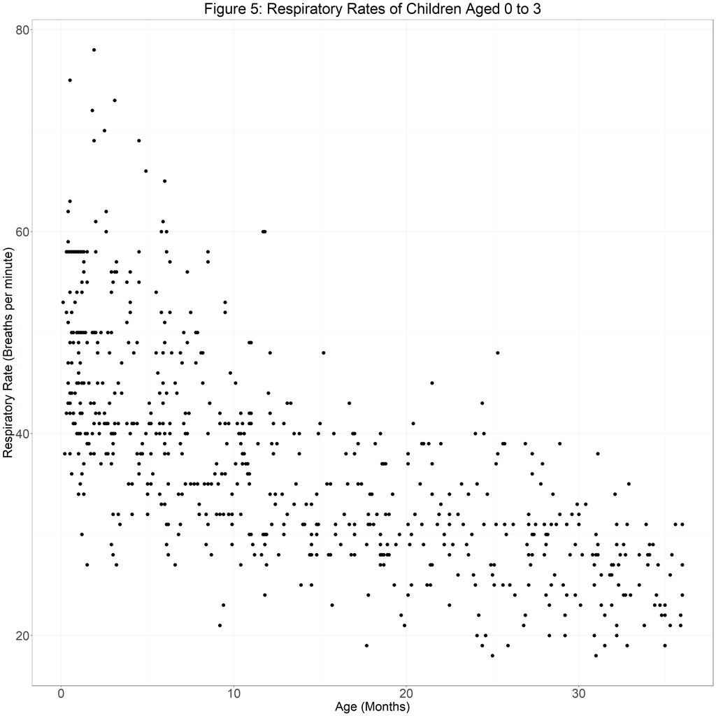

```r
# load in data
respiratoryrates <- readRDS("RespiratoryRates.rds")

# scatter plot
ggplot(data = respiratoryrates, aes(x = Age, y = Rate)) +
  geom_point(size = 3) +
  labs(x = "Age (Months)",
       y = "Respiratory Rate (Breaths per minute)",
       title = "Figure 5: Respiratory Rates of Children Aged 0 to 3"
       )
```

## 2.2 Summary of Analysis

In order to identify high respiratory rates for a child of a given age, I have found the percentiles of the data.

Denoting respiratory rate in breaths per minute by variable $Y$, we can find the $p^{th}$ percentile, $\text{Pr}(Y \leq q) = p$ for some $p \in [0,1]$. Let us assume that $Y \sim N(\mu($`age`$), \sigma^2)$, so it is normally distributed with constant variance, and also assume that $\mathbb{E}(Y) = \mu($`age`$)$ is linear with `age`.

In order to find the value of $q$ for the $p^{th}$ percentile, we can standardise $Y$ as follows.

$$\text{Pr}\left(\frac{Y -
\mu(\text{age})}{\sigma} \leq \frac{q - \mu(\text{age})}{\sigma}\right)
= p \\
\Rightarrow \Phi\left(\frac{q - \mu(\text{age})}{\sigma}\right) =
p,$$

where $\Phi$ is the cumulative distribution function of the standard normal distribution. Finally we can solve for $q$ to find a function for the respiratory rate at percentile $q$ and any chosen age.

$$q(p,\text{age}) = \mu(\text{age}) +
\sigma \Phi^{-1}(p),$$

where $\Phi^{-1}$ is the quantile function of the standard normal distribution. We can run this in R.

First, as we have assumed $Y \sim N(\mu($`age`$), \sigma^2)$ and $\mu(\text{age})$, we can fit a linear model for respiratory rate as a function of age. We can write

$$Y = \beta_0 + \beta_1 \text{age}_i +
\epsilon_i \text{ with } \epsilon_i \sim N(0,\sigma^2) \text{ for } i =
1, \dots, n.\\
\Rightarrow \mathbb{E}(Y) = \mu(\text{age})_i = \beta_0 +
\beta_1\text{age}_i$$
where $n$ is the total number of observations. We fit this model in R as follows, and extract estimates for $\beta_0, \beta_1$ and $\sigma$.

```r
# fitting a linear model for Y against age
lm_rr <- lm(formula = Rate ~ Age, data = respiratoryrates)

# summary statistics
summary(lm_rr)
```

```
##
## Call:
## lm(formula = Rate ~ Age, data = respiratoryrates)
##
## Residuals:
##     Min      1Q  Median      3Q     Max
## -19.652  -5.432  -0.608   4.589  32.270
##
## Coefficients:
##             Estimate Std. Error t value Pr(>|t|)
## (Intercept) 47.05216    0.50422   93.32   <2e-16 ***
## Age         -0.69571    0.02938  -23.68   <2e-16 ***
## ---
## Signif. codes:  0 '***' 0.001 '**' 0.01 '*' 0.05 '.' 0.1 ' ' 1
##
## Residual standard error: 7.842 on 616 degrees of freedom
## Multiple R-squared:  0.4766, Adjusted R-squared:  0.4758
## F-statistic: 560.9 on 1 and 616 DF,  p-value: < 2.2e-16
```

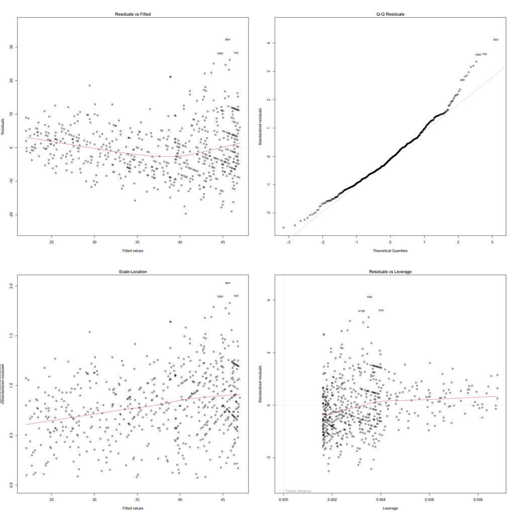

```r
# model residuals
par(mfrow = c(2,2))
plot(lm_rr)
```

From the coefficients of this fitted model, we can find an estimate for the mean respiratory rate for each age as $\hat{\mu}(\text{age}) = \hat{\beta}_0 + \hat{\beta}_1 \times \text{age}$. The estimate for $\hat{\beta}_0$ is $47.05216$ and the estimate for $\hat{\beta}_1$ is $-0.69571$.

We can also deduce $\sigma$ from this model, which is estimated using the residual standard error, $\hat{\sigma} = 7.842$.

The final step for estimating $q$ now is $\Phi^{-1}(p)$, which is found using `qnorm` in R. Figure 6 represents an extract of percentiles found for the data.

```r
# first creating a function for mu
mu_function <- function(age){
  lm_rr$coefficients[1] + lm_rr$coefficients[2] * age
}

# now creating a function for q
q_function <- function(p, age){
  mu_function(age) + summary(lm_rr)$sigma * qnorm(p)
}

# create a vector of percentiles
p_vals <- c(0.01, 0.05, 0.50, 0.95, 0.99)

# apply to our data
percentiles <- sapply(p_vals, function(p) q_function(p, respiratoryrates$Age))

# convert to a df
percentile_data <- data.frame(
  Age = respiratoryrates$Age,
  Percentiles = percentiles
)

colnames(percentile_data)[-1] <- c("1%", "5%", "50%", "95%", "99%")

kable(
  head(percentile_data, 5),
  caption = "Figure 6: Extract of Respiratory Rate Percentile Estimates for Age",
  align = c("l", "c", "c"),
  format = "markdown",
  escape = FALSE
)
```

Figure 6: Extract of Respiratory Rate Percentile Estimates for Age

| Age | 1% | 5% | 50% | 95% | 99% |
| --- | --- | --- | --- | --- | --- |
| 0.1 | 28.73901 | 34.08339 | 46.98259 | 59.88179 | 65.22618 |
| 0.2 | 28.66944 | 34.01382 | 46.91302 | 59.81222 | 65.15661 |
| 0.3 | 28.59986 | 33.94425 | 46.84345 | 59.74265 | 65.08703 |
| 0.3 | 28.59986 | 33.94425 | 46.84345 | 59.74265 | 65.08703 |
| 0.3 | 28.59986 | 33.94425 | 46.84345 | 59.74265 | 65.08703 |

## 2.3 Reference Range of Normal Respiratory Rates in Children Aged 0-3 Years

We can now plot these percentiles for use of medical practitioners. These percentiles can help understand the respiratory rate of a patient relative to the distribution of respiratory rates across a population, to give an indication whether they are high or low. If a patient is above the red line, they have abnormally high rates compared to most patients their age.

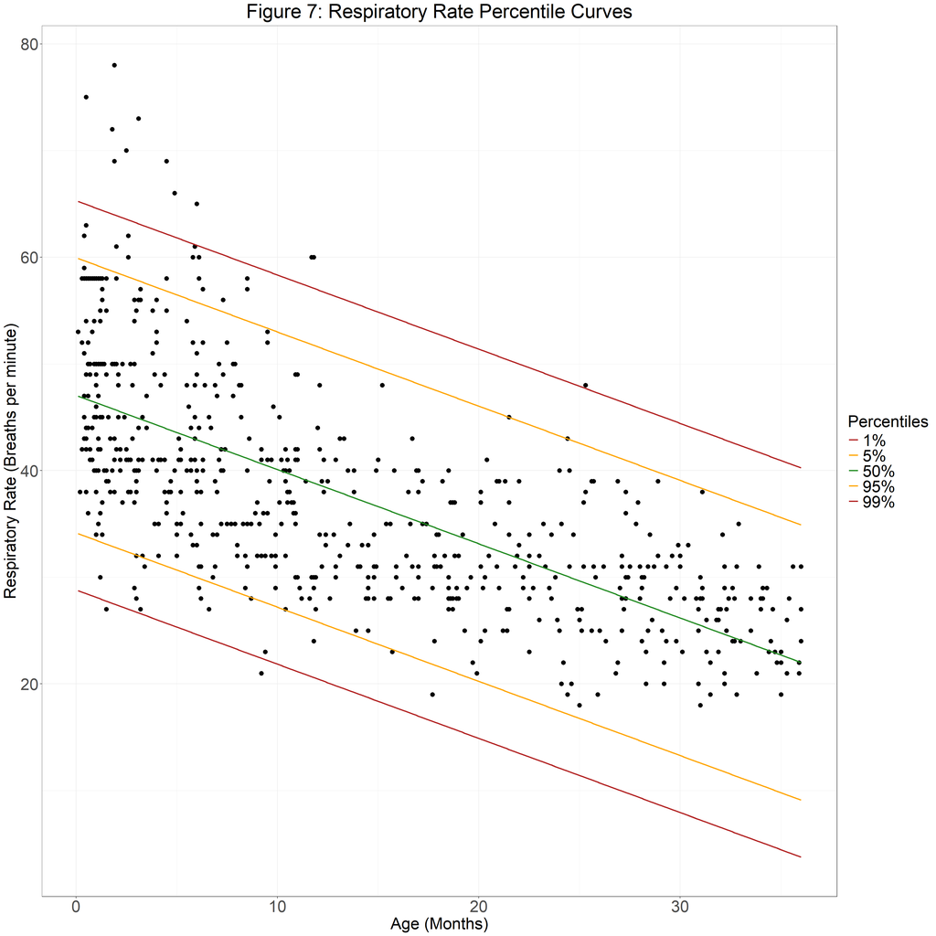

```r
# long format
percentile_long <- pivot_longer(
  percentile_data,
  cols = -Age,
  names_to = "Percentiles",
  values_to = "Rate"
)

# plotting the percentiles on the original scatter plot
ggplot() +
  geom_point(data = respiratoryrates, aes(x = Age, y = Rate), size = 3) +
  geom_line(data = percentile_long, aes(x = Age, y = Rate, colour = Percentiles), size = 1) +
  labs(
    x = "Age (Months)",
    y = "Respiratory Rate (Breaths per minute)",
    title = "Figure 7: Respiratory Rate Percentile Curves"
  ) +
  scale_colour_manual(values = c("1%" = "firebrick",
                                 "5%" = "orange",
                                 "50%" = "forestgreen",
                                 "95%" = "orange",
                                 "99%" = "firebrick"))
```

# 3 Crime Rate in Florida (15 Marks)

Looking again at the 67 counties in Florida, this time I am investigating the relationship between income, education, urbanisation and crime. The dataset has all numerical covariates, with no missing values.

## 3.1 Part A: EDA

The following plots examine the structure of our data. Figure 8 is a heatmap showing the correlation between the covariates and the response variable, crime. We see that all correlations are positive. The plot also shows that urbanisation (the percentage living in an urban environment) is the most correlated covariate with crimes (the annual number of crimes per 1000 residents), while income is the least correlated. We also observe high correlation between all covariates. This is useful to know for when we construct our model, as it should include interactions between covariates.

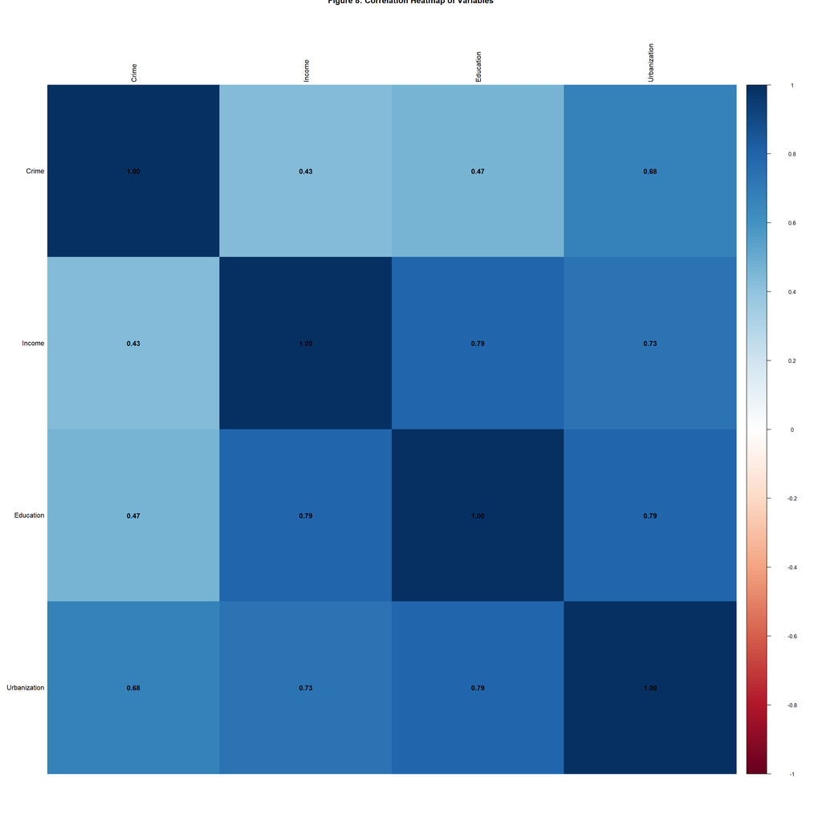

```r
# loading in data
florida <- readRDS("Florida.rds")

# correlation matrix between numeric variables
cor_matrix <- cor(florida[, c("Crime", "Income", "Education", "Urbanization")])

# heatmap of correlations
corrplot(cor_matrix,
         method = "color",
         addCoef.col = "black",
         tl.col = "black",
         title = "Figure 8: Correlation Heatmap of Variables")
```

We can examine the trends of correlation further with a pairplot in Figure 9. This visualises the positive correlations between the variables we are interested in for this analysis.

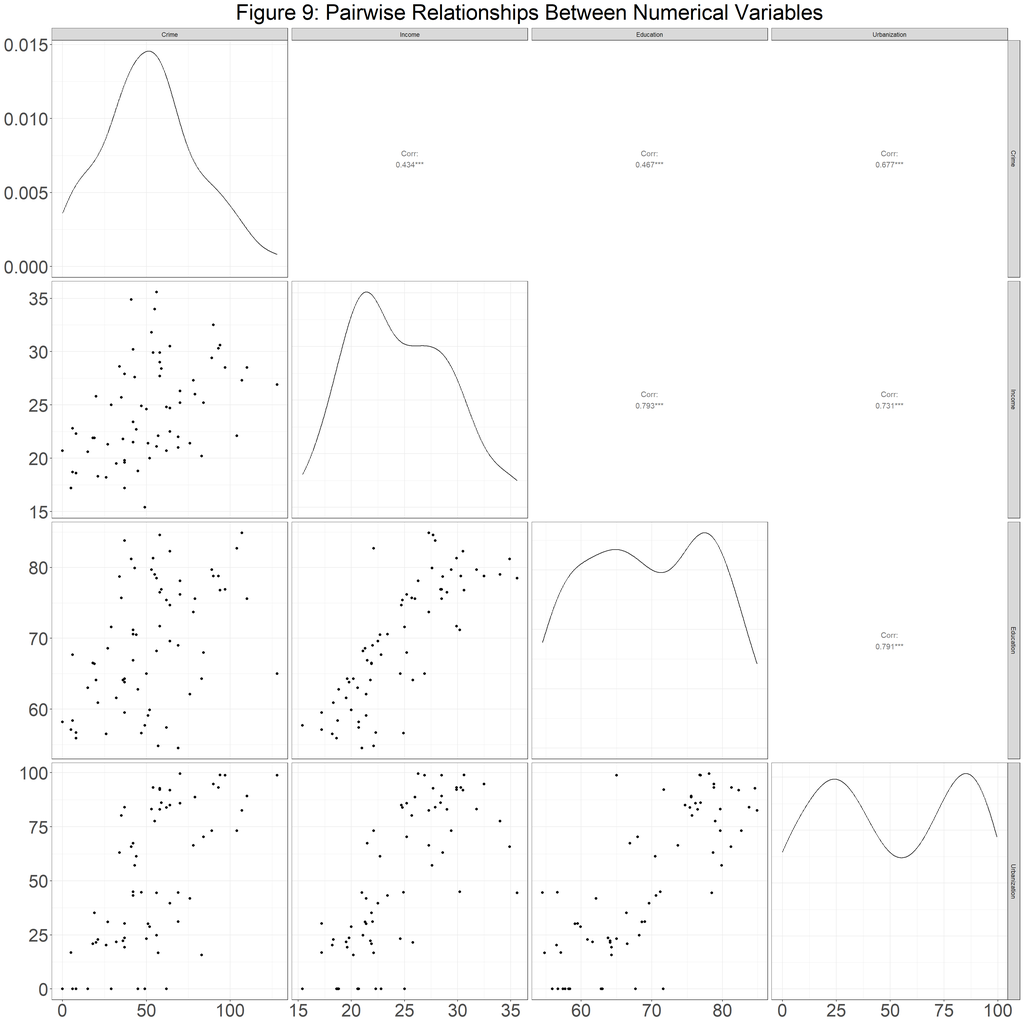

```r
# pairplot
ggpairs(florida[, c("Crime", "Income", "Education", "Urbanization")],
        title = "Figure 9: Pairwise Relationships Between Numerical Variables")
```

To further explore the relationship between each covariate and the response variable, crime, we can fit simple linear regression models of crime rate on each predictor separately. These are

$$\text{crime}_i = \alpha_0 + \alpha_1
\text{income}_i + \epsilon_i, \\
\text{crime}_i = \beta_0 + \beta_1 \text{education}_i + \epsilon_i, \\
\text{crime}_i = \gamma_0 + \gamma_1 \text{urbanisation}_i + \epsilon_i,
\\
\epsilon_i \sim N(0,\sigma^2) \text{ for each county } i = 1, \dots,
67.$$

We can plot these models over the data, in Figure 10.

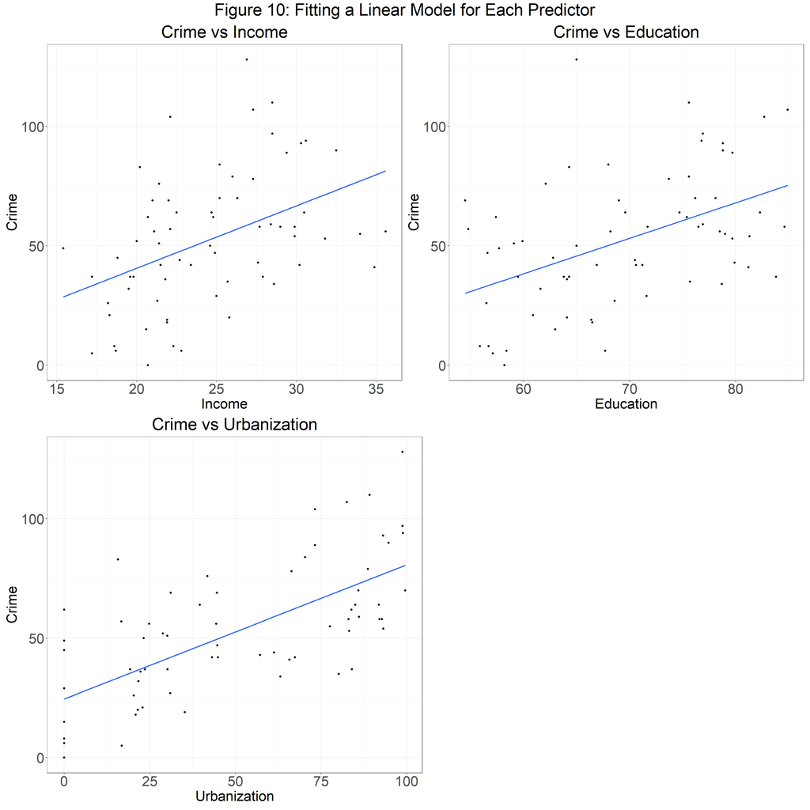

```r
# fitting a model for each predictor

p1 <- ggplot(florida, aes(x = Income, y = Crime)) +
  geom_point() +
  geom_smooth(method = "lm", formula = y ~ x, se = FALSE) +
  labs(title = "Crime vs Income")

p2 <- ggplot(florida, aes(x = Education, y = Crime)) +
  geom_point() +
  geom_smooth(method = "lm", formula = y ~ x, se = FALSE) +
  labs(title = "Crime vs Education")

p3 <- ggplot(florida, aes(x = Urbanization, y = Crime)) +
  geom_point() +
  geom_smooth(method = "lm", formula = y ~ x, se = FALSE) +
  labs(title = "Crime vs Urbanization")

(p1 | p2) /
(p3 | plot_spacer()) +
  plot_annotation(title = "Figure 10: Fitting a Linear Model for Each Predictor")
```

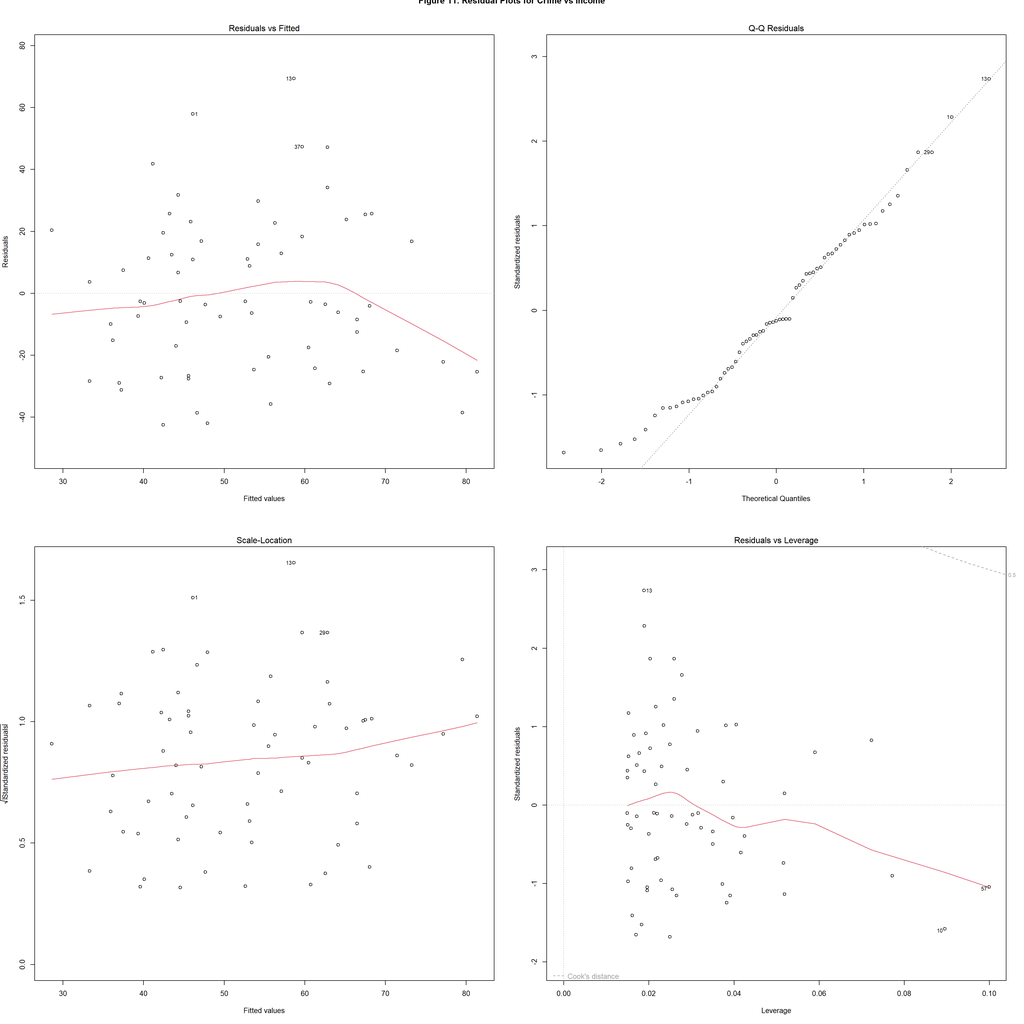

```r
lm_income <- lm(Crime ~ Income, florida)
lm_education <- lm(Crime ~ Education, florida)
lm_urban <- lm(Crime ~ Urbanization, florida)

par(mfrow = c(2,2))
plot(lm_income)
title("Figure 11: Residual Plots for Crime vs Income", outer = TRUE)
```

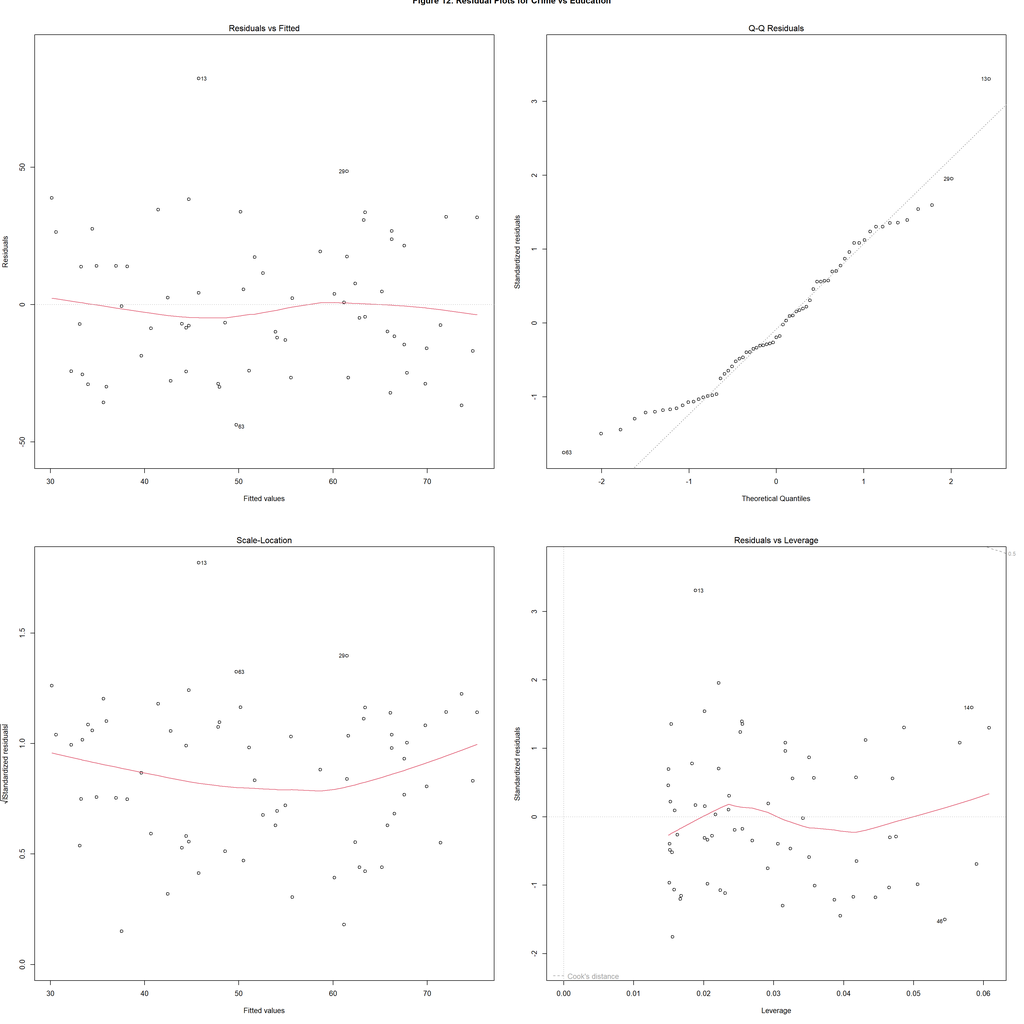

```r
par(mfrow = c(2,2))
plot(lm_education)
title("Figure 12: Residual Plots for Crime vs Education", outer = TRUE)
```

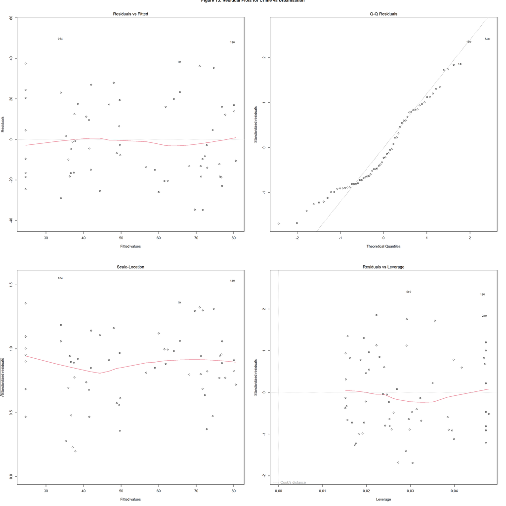

```r
par(mfrow = c(2,2))
plot(lm_urban)
title("Figure 13: Residual Plots for Crime vs Urbanisation", outer = TRUE)
```

## 3.2 Part B: Fitting Interactions

In order to capture the correlation observed in Figure 8, we can expand the linear models above to include interactions. The following three models look at all possible models with two predictors and interactions:

$$m_1 : \text{crime}_i = \alpha_0 +
\alpha_1 \text{income}_i + \alpha_2\text{education}_i + \alpha_3
(\text{income}_i \cdot \text{education}_i) + \epsilon_i, \\
m_2: \text{crime}_i = \beta_0 + \beta_1 \text{education}_i + \beta_2
\text{urbanisation}_i + \beta_3 (\text{education}_i :
\text{urbanisation}_i) + \epsilon_i, \\
m_3 : \text{crime}_i = \gamma_0 + \gamma_1 \text{urbanisation}_i +
\gamma_2 \text{income}_i + \gamma_3 (\text{urbanisation}_i :
\text{income}_i) + \epsilon_i, \\
\epsilon_i \sim N(0, \sigma^2) \text{ for each county } i = 1, \dots,
67.$$

Additionally, we can fit a single model with all interactions,

$$m_{full} : \text{crime}_i = \lambda_0 +
\lambda_1 \text{income}_i + \lambda_2 \text{education}_i + \lambda_3
\text{urbanisation}_i + \\
\lambda_4 (\text{income}_i \cdot \text{education}_i) + \\
\lambda_5 (\text{education}_i : \text{urbanisation}_i) + \\
\lambda_6 (\text{urbanisation}_i : \text{income}_i) + \epsilon_i \\
\epsilon_i \sim N(0, \sigma^2) \text{ for each county } i = 1, \dots,
67.$$

```r
# models
m1 <- lm(Crime ~ Income * Education, florida)
m2 <- lm(Crime ~ Education * Urbanization, florida)
m3 <- lm(Crime ~ Urbanization * Income, florida)
mfull <- lm(Crime ~ (Income + Education + Urbanization)^2, florida)

# find coefficients of full model
full_coef_names <- rownames(summary(mfull)$coef)

# create a function to find summary stats for each model
summary_function_aligned <- function(model, full_coef_names){
  coefs <- summary(model)$coef
  ci <- confint(model)

  stats <- rep(NA, length(full_coef_names) * 2)  # estimate + CI
  names(stats) <- rep(full_coef_names, each = 2)

  for(i in rownames(coefs)){
    idx <- which(full_coef_names == i)
    if(length(idx) > 0){
      stats[2*idx - 1] <- round(coefs[i,1], 4)                      # estimate
      stats[2*idx] <- paste0("(", round(ci[i,1],4), ", ", round(ci[i,2],4), ")")  # CI
    }
  }
  return(stats)
}

interactions_table <- data.frame(
  Coefficient = c(rbind(full_coef_names, paste0("95% CI ", full_coef_names))),
  Model1 = summary_function_aligned(m1, full_coef_names),
  Model2 = summary_function_aligned(m2, full_coef_names),
  Model3 = summary_function_aligned(m3, full_coef_names),
  Modelfull = summary_function_aligned(mfull, full_coef_names)
)

kable(
  interactions_table,
  caption = "Figure 14: Summary Table Comparing Interaction Models",
  align = c("l", "c", "c", "c", "c"),
  format = "markdown",
  escape = FALSE
)
```

Figure 14: Summary Table Comparing Interaction Models

| Coefficient | Model1 | Model2 | Model3 | Modelfull |
| --- | --- | --- | --- | --- |
| (Intercept) | -330.4969 | 19.3175 | 36.9426 | -198.9489 |
| 95% CI (Intercept) | (-656.7241, -4.2697) | (-80.517, 119.1521) | (-24.8449, 98.73) | (-557.3211, 159.4233) |
| Income | 13.4249 | NA | -0.6537 | 8.0692 |
| 95% CI Income | (-0.791, 27.6408) | NA | (-3.5186, 2.2112) | (-8.0387, 24.1772) |
| Education | 5.0586 | 0.034 | NA | 4.0125 |
| 95% CI Education | (0.3795, 9.7378) | (-1.5524, 1.6203) | NA | (-1.8251, 9.8502) |
| Urbanization | NA | 1.5143 | 0.7091 | 0.6226 |
| 95% CI Urbanization | NA | (-0.2204, 3.249) | (-0.4722, 1.8904) | (-1.7224, 2.9677) |
| Income:Education | -0.1715 | NA | NA | -0.1492 |
| 95% CI Income:Education | (-0.366, 0.023) | NA | NA | (-0.3894, 0.0911) |
| Income:Urbanization | NA | NA | NA | 0.0442 |
| 95% CI Income:Urbanization | NA | NA | NA | (-0.03, 0.1185) |
| Education:Urbanization | NA | -0.012 | NA | -0.0152 |
| 95% CI Education:Urbanization | NA | (-0.0369, 0.0128) | NA | (-0.0501, 0.0196) |

# 4 Course Evaluations at the University of Texas at Austin (45 Marks)